# Lab 4

Sofia Ingersoll

2024-05-07

Lab 4 Assignment: Due May 7 at 11:59pm

```r
knitr::opts_chunk$set(echo = TRUE, message = FALSE, warning = FALSE)

# reproducibility
set.seed(1234)

# load libraries
# naive-bayes
library(vip)
library(discrim)
library(tidytext)
library(tidyverse)
library(tidymodels)
library(textrecipes)


library(doParallel)  # for parallel backend to foreach
library(foreach)     # for parallel processing with for loops
library(ranger)
library(parsnip)
library(yardstick)

# load data
urlfile ="https://raw.githubusercontent.com/MaRo406/EDS-231-text-sentiment/main/data/climbing_reports_model_dat.csv"
incidents_df<-readr::read_csv(url(urlfile),
                              show_col_types = FALSE)
```

```r
incidents2class <- incidents_df %>%
  mutate(fatal = factor(if_else(
                        is.na(Deadly),
                        "non-fatal", "fatal")))


incidents_split <- initial_split(incidents2class,
                                 prop = 0.8,
                                 strata = fatal)

incidents_train <- training(incidents_split)
incidents_test <- testing(incidents_split)
```

```r
incidents_rec <- recipe(fatal ~ Text, data = incidents_train)
```

```r
recipe <- incidents_rec %>%
  step_tokenize(Text) %>%
  # max 5000 is perfect performance
  step_tokenfilter(Text, max_tokens = 1000) %>%
  step_tfidf(Text)

# cross validation folds
incidents_folds <- vfold_cv(incidents_train,
                            v = 5)
```

1. Select another classification algorithm. [Random Forest]
2. Conduct an initial out-of-the-box model fit on the training data and prediction on the test data. Assess the performance of this initial model.

```r
#~~~~~~~~~~~~~~~~~~~~~~~~~~~~~~~~~~~~~~~~~~~~~~~~~~~~~~~~~~~~~~~~~~~~~~~~~~~~~~~
# ----                       Tuning Random Forest                           ----
#~~~~~~~~~~~~~~~~~~~~~~~~~~~~~~~~~~~~~~~~~~~~~~~~~~~~~~~~~~~~~~~~~~~~~~~~~~~~~~~
# ensemble of decision trees
# mtry subsets at each parameter to create tree (must be n-1 no. predictors)
# trees is no. of tree models
rf_model <- rand_forest(trees = 500) %>%
  # this is a package loaded in libs
  set_engine('ranger') %>%
  set_mode('classification')

#~~~~~~~~~~~~~~~~~~~~~~~~~~~~~~~~~~~~~~~~~~~~~~~~~~~~~~~~~~~~~~~~~~~~~~~~~~~~~~~
# ----                           Workflow                                   ----
#~~~~~~~~~~~~~~~~~~~~~~~~~~~~~~~~~~~~~~~~~~~~~~~~~~~~~~~~~~~~~~~~~~~~~~~~~~~~~~~
# establish wkflw for model
rf_workflow <- workflow() %>%
  add_model(rf_model) %>%
  add_recipe(recipe)


#~~~~~~~~~~~~~~~~~~~~~~~~~~~~~~~~~~~~~~~~~~~~~~~~~~~~~~~~~~~~~~~~~~~~~~~~~~~~~~~
# ----                             Fit Model                                ----
#~~~~~~~~~~~~~~~~~~~~~~~~~~~~~~~~~~~~~~~~~~~~~~~~~~~~~~~~~~~~~~~~~~~~~~~~~~~~~~~
# Fit the model
train_fit_rf <- fit_resamples(
  rf_workflow,
  incidents_folds,
  control = control_resamples(save_pred = TRUE)
)
#~~~~~~~~~~~~~~~~~~~~~~~~~~~~~~~~~~~~~~~~~~~~~~~~~~~~~~~~~~~~~~~~~~~~~~~~~~~~~~~
# ----                       Collect Metrics                                ----
#~~~~~~~~~~~~~~~~~~~~~~~~~~~~~~~~~~~~~~~~~~~~~~~~~~~~~~~~~~~~~~~~~~~~~~~~~~~~~~~
rf_metrics <- collect_metrics(train_fit_rf, metric = "roc_auc")

rf_predictions <- collect_predictions(train_fit_rf, metric = "roc_auc")

rf_predictions
```

```
## # A tibble: 2,215 × 7
##    id    .pred_fatal `.pred_non-fatal`  .row .pred_class fatal .config
##    <chr>       <dbl>             <dbl> <int> <fct>       <fct> <chr>
##  1 Fold1       0.127             0.873    11 non-fatal   fatal Preprocessor1_Mo…
##  2 Fold1       0.516             0.484    13 fatal       fatal Preprocessor1_Mo…
##  3 Fold1       0.353             0.647    19 non-fatal   fatal Preprocessor1_Mo…
##  4 Fold1       0.642             0.358    21 fatal       fatal Preprocessor1_Mo…
##  5 Fold1       0.552             0.448    37 fatal       fatal Preprocessor1_Mo…
##  6 Fold1       0.389             0.611    43 non-fatal   fatal Preprocessor1_Mo…
##  7 Fold1       0.609             0.391    53 fatal       fatal Preprocessor1_Mo…
##  8 Fold1       0.481             0.519    54 non-fatal   fatal Preprocessor1_Mo…
##  9 Fold1       0.189             0.811    56 non-fatal   fatal Preprocessor1_Mo…
## 10 Fold1       0.193             0.807    59 non-fatal   fatal Preprocessor1_Mo…
## # ℹ 2,205 more rows
```

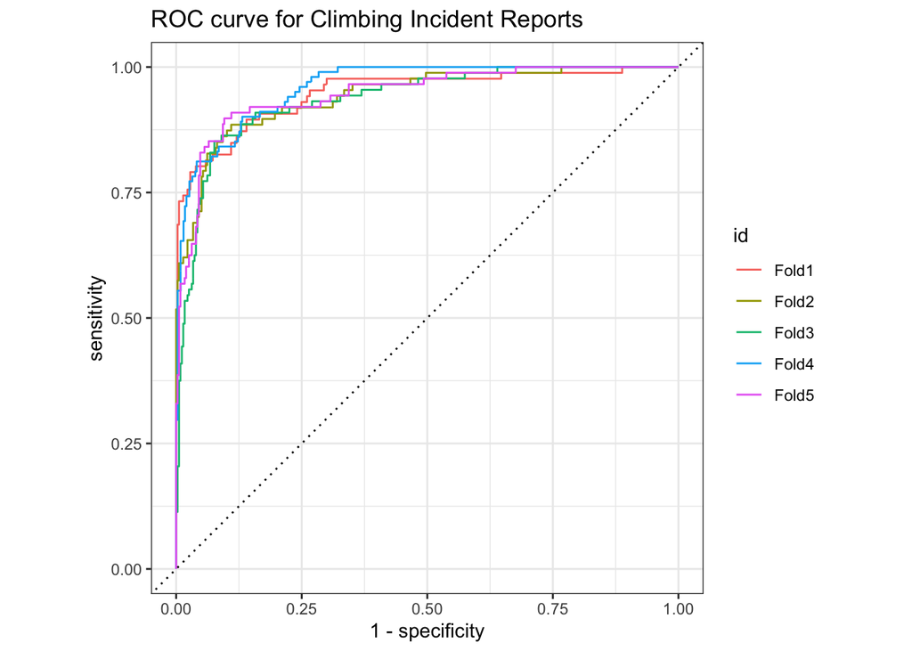

```r
#~~~~~~~~~~~~~~~~~~~~~~~~~~~~~~~~~~~~~~~~~~~~~~~~~~~~~~~~~~~~~~~~~~~~~~~~~~~~~~~
# ----                        Visual of Fit Model                          ----
#~~~~~~~~~~~~~~~~~~~~~~~~~~~~~~~~~~~~~~~~~~~~~~~~~~~~~~~~~~~~~~~~~~~~~~~~~~~~~~~
# visualize model
# create confusion matrix
rf_cm <- rf_predictions %>%
  conf_mat(truth = fatal,
           estimate = .pred_class) %>%
  # plot confusion matrix with heatmap
  autoplot(type = "heatmap") +
  # change theme
  theme_bw() +
  theme(axis.text.x = element_text(angle = 30,
                                   hjust=1)) +
  #rotate axis labels
  labs(title = "Random Forest")


rf_predictions %>%
  group_by(id) %>%
  roc_curve(truth = fatal, .pred_fatal) %>%
  autoplot() +
  labs(title = "ROC curve for Climbing Incident Reports")
```

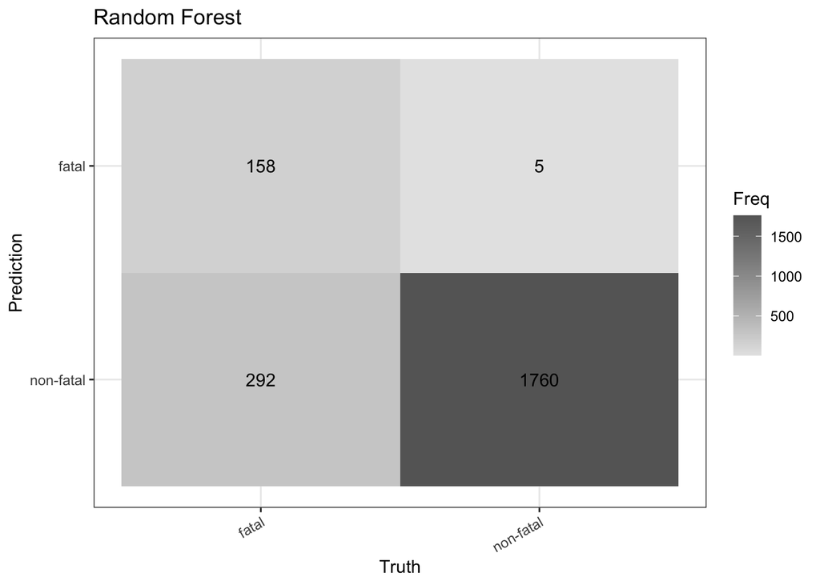

```r
rf_cm
```

3. Select the relevant hyperparameters for your algorithm and tune your model.
4. Conduct a model fit using your newly tuned model specification. How does it compare to your out-of-the-box model?

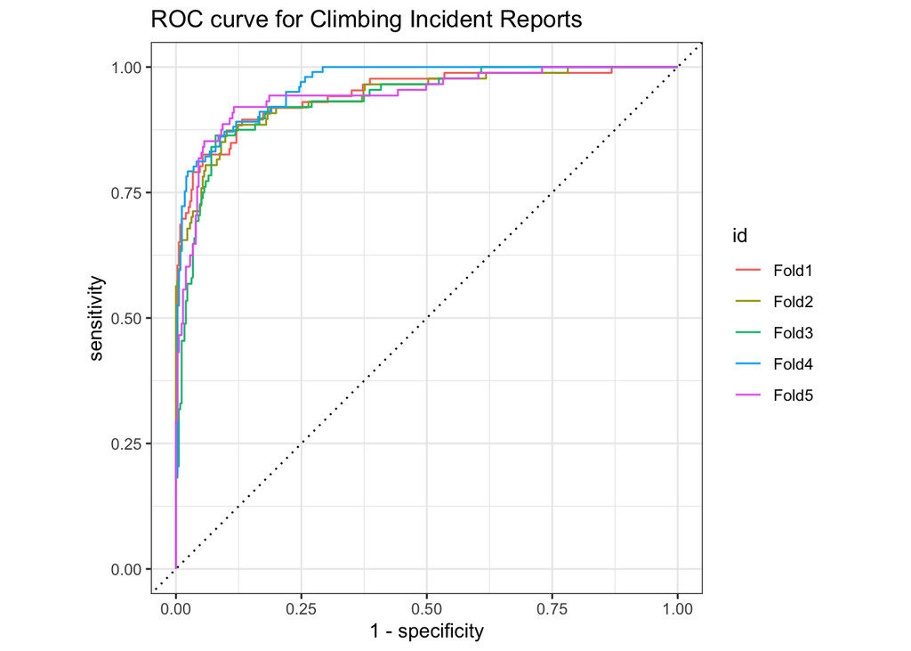

```r
#~~~~~~~~~~~~~~~~~~~~~~~~~~~~~~~~~~~~~~~~~~~~~~~~~~~~~~~~~~~~~~~~~~~~~~~~~~~~~~~
# ----                       Tuning Random Forest                           ----
#~~~~~~~~~~~~~~~~~~~~~~~~~~~~~~~~~~~~~~~~~~~~~~~~~~~~~~~~~~~~~~~~~~~~~~~~~~~~~~~
# ensemble of decision trees
# mtry subsets at each parameter to create tree (must be n-1 no. predictors)
# trees is no. of tree models
rf_tune_model <- rand_forest(trees = tune()) %>%
  # this is a package loaded in libs
  set_engine('ranger') %>%
  set_mode('classification')

#~~~~~~~~~~~~~~~~~~~~~~~~~~~~~~~~~~~~~~~~~~~~~~~~~~~~~~~~~~~~~~~~~~~~~~~~~~~~~~~
# ----                           Workflow                                   ----
#~~~~~~~~~~~~~~~~~~~~~~~~~~~~~~~~~~~~~~~~~~~~~~~~~~~~~~~~~~~~~~~~~~~~~~~~~~~~~~~
# establish wkflw for model
rf_tune_workflow <- workflow() %>%
  add_model(rf_tune_model) %>%
  add_recipe(recipe)


#~~~~~~~~~~~~~~~~~~~~~~~~~~~~~~~~~~~~~~~~~~~~~~~~~~~~~~~~~~~~~~~~~~~~~~~~~~~~~~~
# ----                        Cross Validation                              ----
#~~~~~~~~~~~~~~~~~~~~~~~~~~~~~~~~~~~~~~~~~~~~~~~~~~~~~~~~~~~~~~~~~~~~~~~~~~~~~~~
# use cross validation to tune mtry and treesfor 5 parameters combinations
# this takes a very long time to run
rf_cv_tune = rf_tune_workflow %>%
  tune_grid(resamples = incidents_folds,
            grid = 5)

#~~~~~~~~~~~~~~~~~~~~~~~~~~~~~~~~~~~~~~~~~~~~~~~~~~~~~~~~~~~~~~~~~~~~~~~~~~~~~~~
# ----                         Finalize Workflow                            ----
#~~~~~~~~~~~~~~~~~~~~~~~~~~~~~~~~~~~~~~~~~~~~~~~~~~~~~~~~~~~~~~~~~~~~~~~~~~~~~~~
# store the best tuning metrics
rf_tune_best <- show_best(rf_cv_tune, n = 1, metric = "roc_auc")

# finalize workflow
rf_tune_final <-  finalize_workflow(rf_tune_workflow,
                                    rf_tune_best)

#~~~~~~~~~~~~~~~~~~~~~~~~~~~~~~~~~~~~~~~~~~~~~~~~~~~~~~~~~~~~~~~~~~~~~~~~~~~~~~~
# ----                             Fit Model                                ----
#~~~~~~~~~~~~~~~~~~~~~~~~~~~~~~~~~~~~~~~~~~~~~~~~~~~~~~~~~~~~~~~~~~~~~~~~~~~~~~~
# similar functions here.
# Fit the model to resampled data
train_fit_rf_tune <- fit_resamples(rf_tune_final,
                                   incidents_folds,
                                   control = control_resamples(save_pred = TRUE))

#~~~~~~~~~~~~~~~~~~~~~~~~~~~~~~~~~~~~~~~~~~~~~~~~~~~~~~~~~~~~~~~~~~~~~~~~~~~~~~~
# ----                       Collect Metrics                                ----
#~~~~~~~~~~~~~~~~~~~~~~~~~~~~~~~~~~~~~~~~~~~~~~~~~~~~~~~~~~~~~~~~~~~~~~~~~~~~~~~
# Collect metrics
rf_tune_metrics <- collect_metrics(train_fit_rf_tune, metric = "roc_auc")

# Get predictions on the test set
rf_tune_predictions <- collect_predictions(train_fit_rf_tune, new_data = incidents_test)

#~~~~~~~~~~~~~~~~~~~~~~~~~~~~~~~~~~~~~~~~~~~~~~~~~~~~~~~~~~~~~~~~~~~~~~~~~~~~~~~
# ----                        Visual of Fit Model                          ----
#~~~~~~~~~~~~~~~~~~~~~~~~~~~~~~~~~~~~~~~~~~~~~~~~~~~~~~~~~~~~~~~~~~~~~~~~~~~~~~~
# visualize model
# create confusion matrix
rf_tune_cm <- rf_tune_predictions %>%
  conf_mat(truth = fatal,
           estimate = .pred_class) %>%
  # plot confusion matrix with heatmap
  autoplot(type = "heatmap") +
  # change theme
  theme_bw() +
  theme(axis.text.x = element_text(angle = 30,
                                   hjust=1)) +
  #rotate axis labels
  labs(title = "Random Forest")


rf_tune_predictions %>%
  group_by(id) %>%
  roc_curve(truth = fatal, .pred_fatal) %>%
  autoplot() +
  labs(title = "ROC curve for Climbing Incident Reports")
```

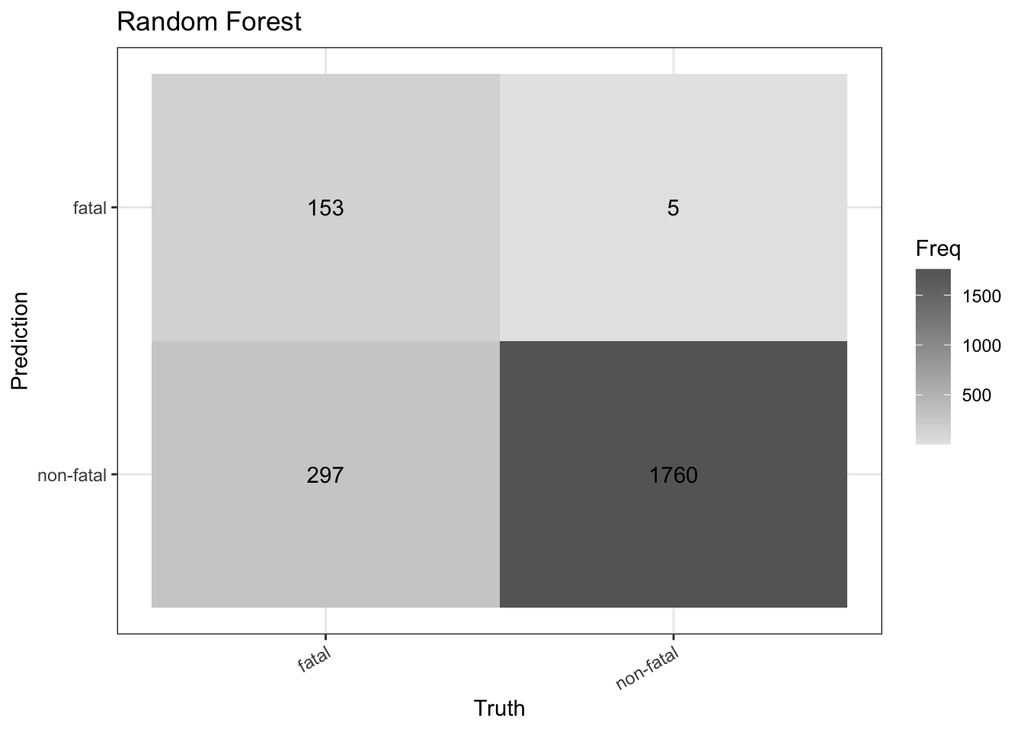

```r
rf_tune_cm
```

5. 1. Use variable importance to determine the terms most highly associated with non-fatal reports? What about terms associated with fatal reports? OR
   2. If you aren’t able to get at variable importance with your selected algorithm, instead tell me how you might in theory be able to do it. Or how you might determine the important distinguishing words in some other way.

My attempts to use variable importance were not fruitful, but I’ve left my attempts. Random Forests ranger does not provid eModel-specific variable importance scores. In the future, I would use a model like xgboost that provides the scores.

```r
# Visualize fit model
# Error: Model-specific variable importance scores are currently not available for this type of model.
# this worked when i was trying to use xgboost while practicing
train_fit_rf_tune %>%
  vip(geom = 'col',
      aesthetics = list(fill = 'midnightblue'))


# Extract variable importance scores
importance_scores <- best_model$.fit$variable.importance

# Get variable names
variable_names <- names(importance_scores)

# Create a data frame to store variable names and importance scores
variable_importance <- data.frame(
  variable = variable_names,
  importance = importance_scores
)

# Sort variables by importance for non-fatal reports
non_fatal_importance <- variable_importance %>%
  arrange(desc(importance))

# Filter terms associated with non-fatal reports
terms_non_fatal <- non_fatal_importance$variable[1:10]  # Adjust the number of terms as needed

# Sort variables by importance for fatal reports
fatal_importance <- variable_importance %>%
  arrange(importance)

# Filter terms associated with fatal reports
terms_fatal <- fatal_importance$variable[1:10]  # Adjust the number of terms as needed

# Display the top terms associated with non-fatal and fatal reports
print("Top terms associated with non-fatal reports:")
print(terms_non_fatal)

print("Top terms associated with fatal reports:")
print(terms_fatal)
```

6. Predict fatality of the reports in the test set. Compare this prediction performance to that of the Naive Bayes and Lasso models. Why do you think your model performed as it did, relative to the other two?

NB model performed the worst, followed by the RF models, leaving the Lasso model in the lead. This is likely because Lasso performs feature selection by shrinking some coefficients to zero, effectively selecting only the most relevant features.

```r
#~~~~~~~~~~~~~~~~~~~~~~~~~~~~
# ---        NB Spec.    ----
#~~~~~~~~~~~~~~~~~~~~~~~~~~~~
nb_spec <- naive_Bayes() %>%
  set_mode("classification") %>%
  set_engine("naivebayes")


#~~~~~~~~~~~~~~~~~~~~~~~~~~~~
# ---        NB Wkflw    ----
#~~~~~~~~~~~~~~~~~~~~~~~~~~~~
nb_wf <- workflow() %>%
  add_recipe(recipe) %>%
  add_model(nb_spec)


#~~~~~~~~~~~~~~~~~~~~~~~~~~~~
# ---       fit model    ----
#~~~~~~~~~~~~~~~~~~~~~~~~~~~~
nb_rs <- fit_resamples(
  nb_wf,
  incidents_folds,
  control = control_resamples(save_pred = T)
)


#~~~~~~~~~~~~~~~~~~~~~~~~~~~~
# --- collect metrics    ----
#~~~~~~~~~~~~~~~~~~~~~~~~~~~~
nb_rs_metrics <- collect_metrics(nb_rs)
nb_rs_predictions <- collect_predictions(nb_rs)

nb_rs_predictions
```

```
## # A tibble: 2,215 × 7
##    id    .pred_fatal `.pred_non-fatal`  .row .pred_class fatal .config
##    <chr>       <dbl>             <dbl> <int> <fct>       <fct> <chr>
##  1 Fold1    1.95e-11              1.00    11 non-fatal   fatal Preprocessor1_Mo…
##  2 Fold1    2.57e-10              1.00    13 non-fatal   fatal Preprocessor1_Mo…
##  3 Fold1    2.61e-44              1       19 non-fatal   fatal Preprocessor1_Mo…
##  4 Fold1    3.59e-49              1       21 non-fatal   fatal Preprocessor1_Mo…
##  5 Fold1    7.38e-52              1       37 non-fatal   fatal Preprocessor1_Mo…
##  6 Fold1    5.97e-57              1       43 non-fatal   fatal Preprocessor1_Mo…
##  7 Fold1    2.99e-84              1       53 non-fatal   fatal Preprocessor1_Mo…
##  8 Fold1    2.45e-70              1       54 non-fatal   fatal Preprocessor1_Mo…
##  9 Fold1    2.95e-84              1       56 non-fatal   fatal Preprocessor1_Mo…
## 10 Fold1    8.66e-42              1       59 non-fatal   fatal Preprocessor1_Mo…
## # ℹ 2,205 more rows
```

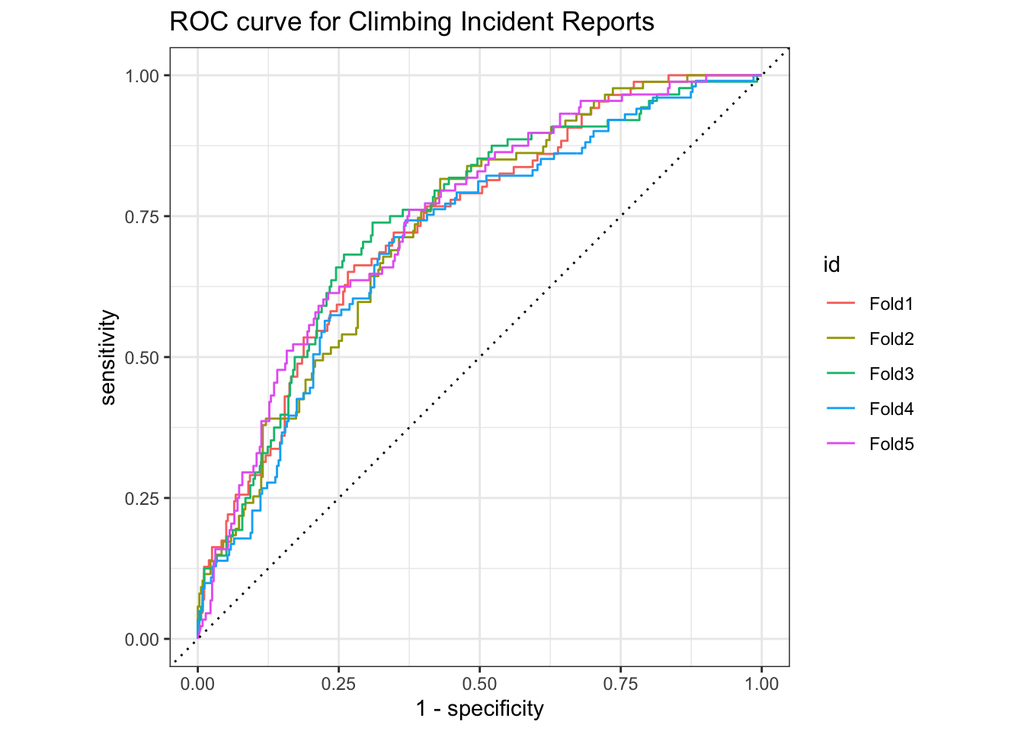

```r
#~~~~~~~~~~~~~~~~~~~~~~~~~~~~
# ---       visualize    ----
#~~~~~~~~~~~~~~~~~~~~~~~~~~~~
nb_rs_predictions %>%
  group_by(id) %>%
  roc_curve(truth = fatal, .pred_fatal) %>%
  autoplot() +
  labs(title = "ROC curve for Climbing Incident Reports")
```

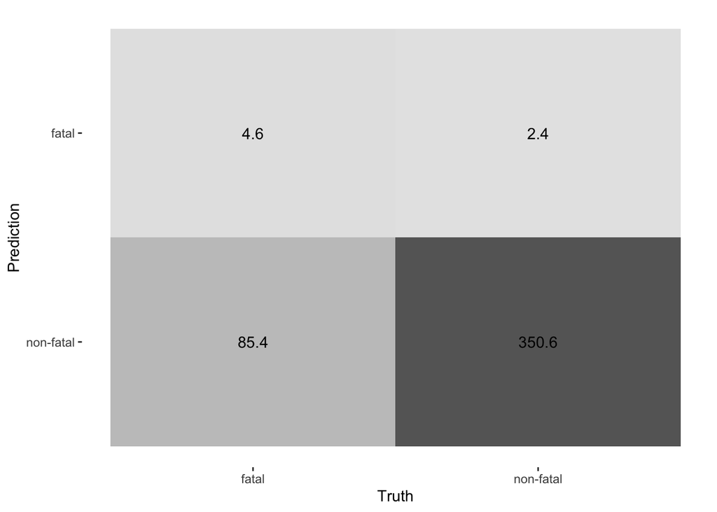

```r
conf_mat_resampled(nb_rs, tidy = F) %>%
  autoplot(type = "heatmap")
```

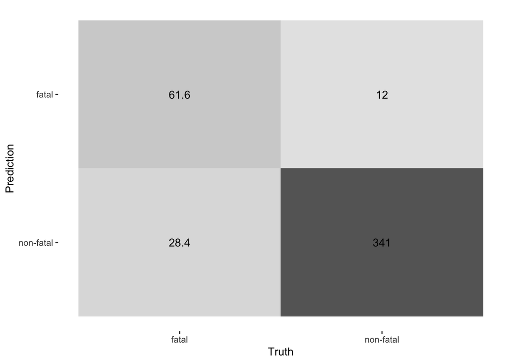

```r
#~~~~~~~~~~~~~~~~~~~~~~~~~~~~
# --- Penalty Tuning Spec----
#~~~~~~~~~~~~~~~~~~~~~~~~~~~~
tune_spec <- logistic_reg(penalty = tune(),
                          # mixture used for feature selection
                          # tells model to use L1 penalty term, this drive all the way to 0
                          # L2 would only do feature selection close to zero
                          mixture = 1) %>%
  set_mode('classification') %>%
  set_engine('glmnet')

#~~~~~~~~~~~~~~~~~~~~~~~~~~~~
# --- Create Lambda Grid ----
#~~~~~~~~~~~~~~~~~~~~~~~~~~~~
lambda_grid <- grid_regular(penalty(),
                            # try this many values for hyperparam
                            levels = 30)

#~~~~~~~~~~~~~~~~~~~~~~~~~~~~
# ----     Tune Wkflw.   ----
#~~~~~~~~~~~~~~~~~~~~~~~~~~~~
tune_wf <- workflow() %>%
  add_recipe(recipe) %>%
  add_model(tune_spec)

# run model 300 times (30 params x 10 folds)
tunes_rs <- tune_grid(
  tune_wf,
  incidents_folds,
  grid = lambda_grid,
  control = control_resamples(save_pred = T)
)

#~~~~~~~~~~~~~~~~~~~~~~~~~~~~
# ----   Fit Resamples   ----
#~~~~~~~~~~~~~~~~~~~~~~~~~~~~
#lasso_rs <- fit_resamples(
 # lasso_wf,
  #incidents_folds,
  #control = control_resamples(save_pred = TRUE))

#~~~~~~~~~~~~~~~~~~~~~~~~~~~~
# ---- Pentalty Show Best----
#~~~~~~~~~~~~~~~~~~~~~~~~~~~~
tune_best_roc <- tunes_rs %>%
  select_best("roc_auc")


#~~~~~~~~~~~~~~~~~~~~~~~~~~~~
# ---- Finalize Workflow ----
#~~~~~~~~~~~~~~~~~~~~~~~~~~~~
final_lasso <- finalize_workflow(tune_wf,
                                 tune_best_roc)

#~~~~~~~~~~~~~~~~~~~~~~~~~~~~
# ---- final fitmetrics  ----
#~~~~~~~~~~~~~~~~~~~~~~~~~~~~
lasso_fit_final <- fit_resamples(final_lasso,
                                 incidents_folds,
                                 control = control_resamples(save_pred = TRUE))


final_lasso <- collect_metrics(lasso_fit_final)

# Extract predictions from the fitted resamples
lasso_predictions <- lasso_fit_final %>%
  collect_predictions()


#~~~~~~~~~~~~~~~~~~~~~~~~~~~~
# ---       visualize    ----
#~~~~~~~~~~~~~~~~~~~~~~~~~~~~
conf_mat_resampled(lasso_fit_final, tidy = F) %>%
  autoplot(type = "heatmap")
```

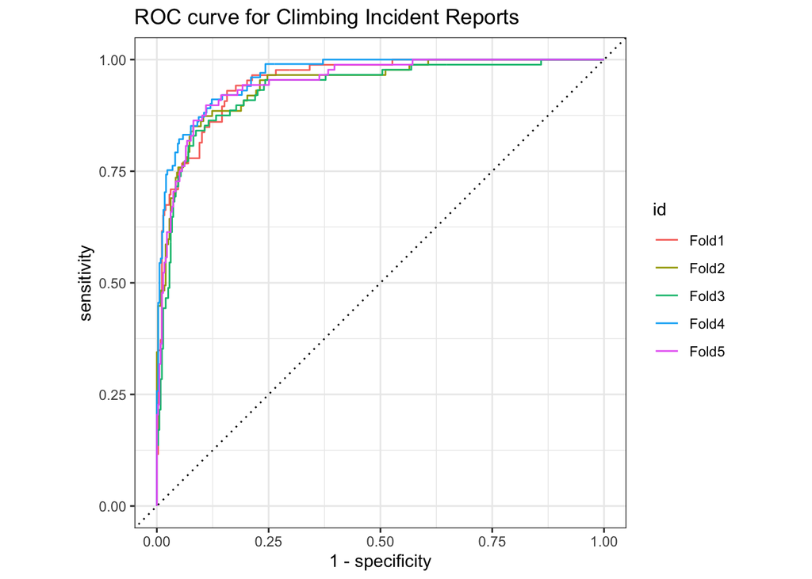

```r
lasso_predictions %>%
  group_by(id) %>%
  roc_curve(truth = fatal, .pred_fatal) %>%
  autoplot() +
  labs(title = "ROC curve for Climbing Incident Reports")
```